# A Bloody and Profane Affair: Exploring Tarantino Films

Martyna Stalmach

2022-06-06

# Introduction

The goal of the project is to explore data on movies directed by Quentin Tarantino. The data was collected by a journalist from FiveThirtyEight.

# Data Processing

The data was loaded directly from the RStudio package. We added columns bled_out_or_cursed, year, and duration containing the following information:

The summary statistics of selected variables are as follows:

Data Frame Summary

df_summary

**Dimensions**: 1894 x 7  
**Duplicates**: 54

| **No** | **Variable** | **Stats / Values** | **Freqs (% of Valid)** | **Graph** | **Valid** | **Missing** |
| --- | --- | --- | --- | --- | --- | --- |
| 1 | movie [character] | 1. Django Unchained 2. Inglorious Basterds 3. Jackie Brown 4. Kill Bill: Vol. 1 5. Kill Bill: Vol. 2 6. Pulp Fiction 7. Reservoir Dogs | 309 ( 16.3% ) 106 ( 5.6% ) 372 ( 19.6% ) 120 ( 6.3% ) 80 ( 4.2% ) 476 ( 25.1% ) 431 ( 22.8% ) |  | 1894 (100.0%) | 0 (0.0%) |
| 2 | profane [logical] | 1. FALSE 2. TRUE | 190 ( 10.0% ) 1704 ( 90.0% ) |  | 1894 (100.0%) | 0 (0.0%) |
| 3 | word [character] | 1. fucking 2. shit 3. fuck 4. n-word 5. ass 6. goddamn 7. motherfucker 8. bitch 9. hell 10. damn [ 50 others ] | 407 ( 23.9% ) 221 ( 13.0% ) 213 ( 12.5% ) 179 ( 10.5% ) 140 ( 8.2% ) 113 ( 6.6% ) 70 ( 4.1% ) 64 ( 3.8% ) 45 ( 2.6% ) 37 ( 2.2% ) 215 ( 12.6% ) |  | 1704 (90.0%) | 190 (10.0%) |
| 4 | minutes_in [numeric] | Mean (sd) : 71.5 (45.1) min ≤ med ≤ max: 0.4 ≤ 70.5 ≤ 160.4 IQR (CV) : 83.2 (0.6) | 1690 distinct values |  | 1894 (100.0%) | 0 (0.0%) |
| 5 | year [numeric] | Mean (sd) : 1998.9 (7.3) min ≤ med ≤ max: 1992 ≤ 1997 ≤ 2012 IQR (CV) : 10 (0) | 1992 : 431 ( 22.8% ) 1994 : 476 ( 25.1% ) 1997 : 372 ( 19.6% ) 2003 : 120 ( 6.3% ) 2004 : 80 ( 4.2% ) 2009 : 106 ( 5.6% ) 2012 : 309 ( 16.3% ) |  | 1894 (100.0%) | 0 (0.0%) |
| 6 | duration [numeric] | Mean (sd) : 141 (26) min ≤ med ≤ max: 99 ≤ 154 ≤ 165 IQR (CV) : 49 (0.2) | 99 : 431 ( 22.8% ) 111 : 120 ( 6.3% ) 137 : 80 ( 4.2% ) 153 : 106 ( 5.6% ) 154 : 476 ( 25.1% ) 160 : 372 ( 19.6% ) 165 : 309 ( 16.3% ) |  | 1894 (100.0%) | 0 (0.0%) |
| 7 | bled_out_or_cursed [character] | 1. bled out 2. cursed | 190 ( 10.0% ) 1704 ( 90.0% ) |  | 1894 (100.0%) | 0 (0.0%) |

Generated by summarytools 1.0.1 ([R](https://www.r-project.org/) version 4.4.2)  
2025-03-20

From the above table, we can infer, for example, the average movie duration, the first and last minute in which a profanity or death occurs, as well as the total number of profanities and deaths across all films.

## Variables Used

| Variable | Description |
| --- | --- |
| *movie* | movie |
| *profane* | whether it’s a profanity (False, True) |
| *word* | spoken word |
| *minutes_in* | time in minutes |
| *bled_out_or_cursed* | bleeding out or curse |
| *year* | release year |
| *duration* | movie duration |

# Analyses

### Topics Covered in the Analysis

1. Analysis of Profanities
- Examined the number of profanities across different time periods.
- Categorized the types of profanities used.
- Analyzed the effect of time on their frequency and type.
2. Analysis of Deaths
- Explored the number and percentage of deaths across various time periods and films.
3. Comparative Analysis
- Investigated instances where a profanity and a death occur simultaneously or within a close time frame.
- Compared the overall numbers of profanities and deaths across films.

## Profanity Analysis

The goal of this analysis is to check if there is any relationship between the number of profanities and the film’s progress, and which types of profanities dominated in each movie.

[figure not shown]

*Reservoir Dogs* is not, however, the most profane movie among those listed here. *Pulp Fiction* contains over a quarter of all the profanities. This is more than twice the number found in *Kill Bill: Vol. 1*, *Kill Bill: Vol. 2*, and *Inglorious Basterds* combined. It’s worth noting, however, that the Kill Bill films are quite specific works of Tarantino, where, amidst the fight scenes, there wasn’t much room for profanity.

```r
# Data pipeline with duration column for percentage intervals
percentage_table <- tarantino %>%
  filter(!is.na(word)) %>%
  group_by(movie) %>%
  mutate(percent_time = cut(
    minutes_in / duration,
    breaks = seq(0, 1, by = 0.25),
    labels = c("0-25%", "25-50%", "50-75%", "75-100%")
  )) %>%
  group_by(percent_time, movie) %>%
  summarise(word_count = n(), .groups = "drop") %>%
  pivot_wider(
    names_from = percent_time,
    values_from = word_count,
    values_fill = 0
  ) %>%
  gt() %>%
  tab_header(
    title = "Word Distribution Across Percentage of Movie Runtime",
    subtitle = "Normalized Using Movie Duration"
  ) %>%
  cols_label(
    `0-25%` = "0-25%",
    `25-50%` = "25-50%",
    `50-75%` = "50-75%",
    `75-100%` = "75-100%"
  ) %>%
  fmt_number(
    columns = everything(),
    decimals = 0
  ) %>%
  opt_table_outline() %>%
  opt_row_striping()

# Display the table
percentage_table
```

Word Distribution Across Percentage of Movie Runtime

Normalized Using Movie Duration

| movie | 0-25% | 25-50% | 50-75% | 75-100% |
| --- | --- | --- | --- | --- |
| Django Unchained | 30 | 62 | 90 | 80 |
| Inglorious Basterds | 15 | 12 | 16 | 15 |
| Jackie Brown | 144 | 75 | 68 | 81 |
| Kill Bill: Vol. 1 | 29 | 18 | 8 | 2 |
| Kill Bill: Vol. 2 | 28 | 11 | 12 | 18 |
| Pulp Fiction | 127 | 82 | 74 | 186 |
| Reservoir Dogs | 113 | 133 | 89 | 86 |

In terms of overall trends, *Reservoir Dogs* stands out for maintaining a consistently high number of profanities across all percentage intervals, particularly peaking in the 25–50% range (133 instances). However, caution should be exercised when analyzing the final time interval (75–100%) for *Kill Bill: Vol. 1* and *Reservoir Dogs*, as their shorter runtimes (111 and 99 minutes, respectively) mean these values represent less runtime compared to longer films.

This analysis highlights both the relative intensity and timing of profanity usage across Tarantino’s films, offering insight into pacing and dialogue density.

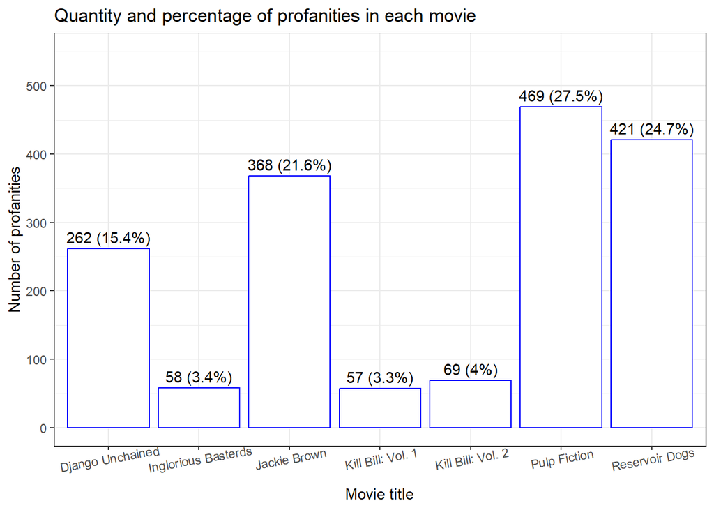

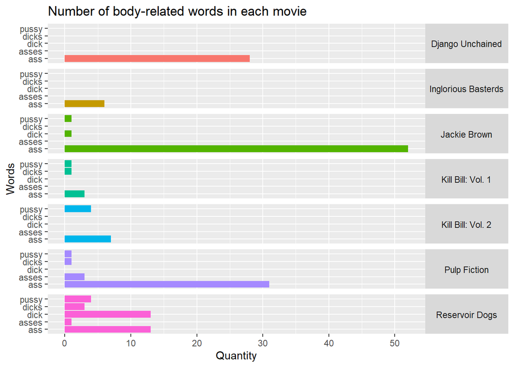

The word “ass” stands out here, appearing repeatedly in every film. Ass-related words are also the largest group among body-related terms. The graph also shows that Reservoir Dogs is the most diverse in this category of vocabulary.

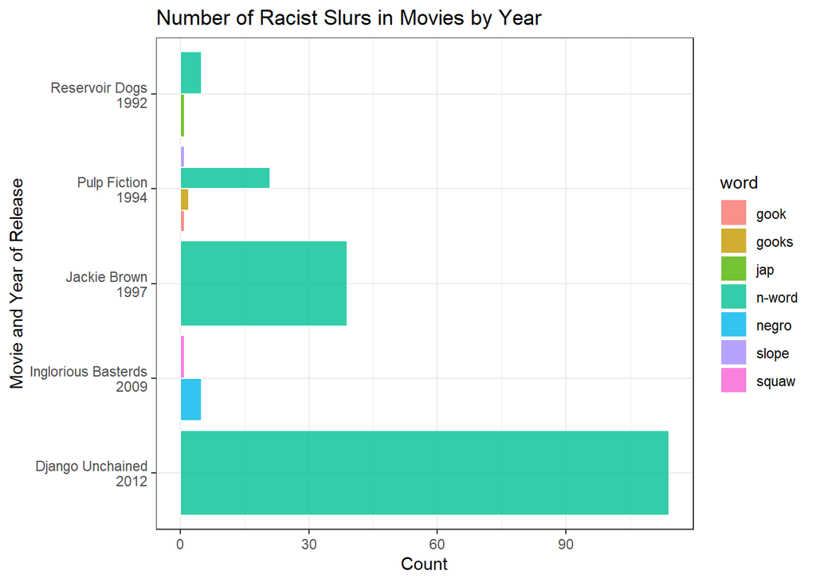

The chart leaves no doubt as to which racist slur is most frequently used. In Django and Jackie Brown, no other slurs were used. However, in the former, it was uttered nearly three times as often. A rising trend in the use of the n-word can be observed (with the exception of Inglorious Basterds).

## Analysis of Bleed-Outs

In this section, the percentage correlation of bleed-outs at specific stages (time intervals) of the movie was re-examined.

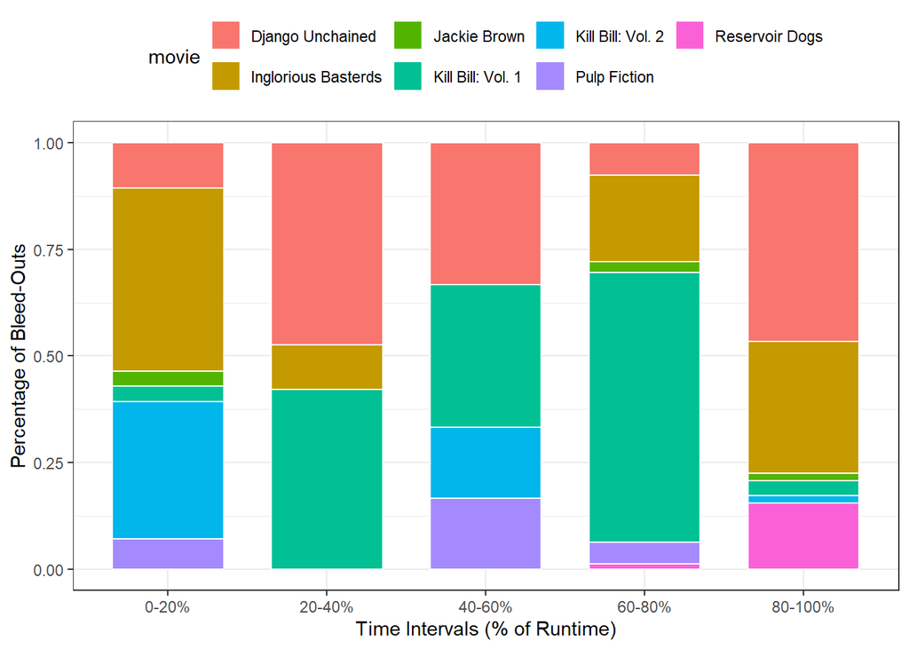

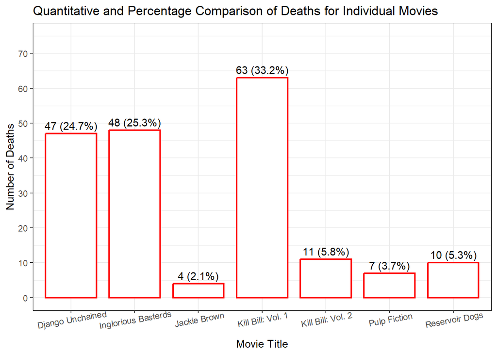

In this analysis, we can see that the highest number of bleed-outs occurs in the movie Kill Bill: Vol. 1. Considering the previous chart, it can be inferred that most of them happened between the 60th and 90th minute.